# Quantitative Genetics – PCB6555

Week 1

Felipe Ferrão, Matias Kirst and Marcio Resende

University of Florida – September, 2020

**Objectives:**

- Discuss population genetic concepts
- Simulate, estimate and analyze relatedness and inbreeding coefficients using molecular data

**Plan for today:**

- 20-25 minutes hands-on
- Graphically show the concepts of inbreeding and drift discussed in the theoretical part
- Using the COANCESTRY software to compute relatedness and inbreeding using molecular data

# Introduction

- Last class we discussed about Hardy-Weinberg equilibrium, a rule that holds true only when individuals in a population mate at random
- Inbreeding is a form of non-random mating, very common in plants
- Inbreeding is based on genetic relationship, since it occurs when two mating individuals have a common ancestror
- Some consequences of inbreeding:
  - Increase the frequency of homozygous across the generations
  - Deleterious alleles are more frequently in homozygotes – reduce the mean fitness of a population
  - Reduce the genetic diversity
- Genetic marker data are widely used to estimate inbreeding and relatedness between individuals in a population in which pedigree records are either lacking or unreliable.

# Population Genetics in R

## Resources

- The January 2017 issue of [Molecular Ecology Resources](https://onlinelibrary.wiley.com/toc/17550998/2017/17/1) describes a series of packages for R that are useful for analysis of population genetic data.
- The Statistical Genetics Task View on the Comprehensive R Archive Network (CRAN) lists more than 30 packages for analysis of genetic data in R.
- [The Population Genetics in R](https://popgen.nescent.org/index.html) site provides tutorials for several kinds of population genetic analysis in R.

## Inbreeding

[interactive chart not shown]

## Drift

[interactive chart not shown]

# Relatedness, Consanguinity and Inbreeding

## Concepts

- Two individuals may have a common ancestor. A simple way of measuring the degree of relatedeness between two individuals is the **coefficient of relationship**. That was originally proposed by [Sewall Wright in 1922](https://aipl.arsusda.gov/publish/other/wright1922.pdf).
- If they are related, both may have two received two copies of the same allele from the ancestor. Such copies are said to be **identical by descent (IBD).**
- The probability that two copies of a gene are IBD is called the **inbreeding coefficient** (*f*).
- **Coefficient of Consanguinity ($r_{xy}$)** proposed by Malecot in 1948 ,is more frequent and represent the probability that two alleles, one chosen at random from each of two individuals, are IBD. It is also called **kinship** , **coancestry**, **parenté** or **parentage**.

**Important**

The capacity to connect individuals using pedigree records or molecular data is the statistical and genetic basis of key concepts in the Quantitative genetic area. For example:

- Prediction of breeding values
- Estimating heritability.

*A spoiler here*: the coancestry explains an important portion of the genetic variation. Namely, the **additive genetic relationship** between two individuals is twice their coancestry. Just keep it in mind for the future.

### Example

- The nine IBD probabilities, relatedness and inbreeding coefficients for some relationships in selfing populations are listed below.
- Relationships can be computed using path coefficients (as presented in the last class). For more complex and long pedigree, we have recursive algorithms.

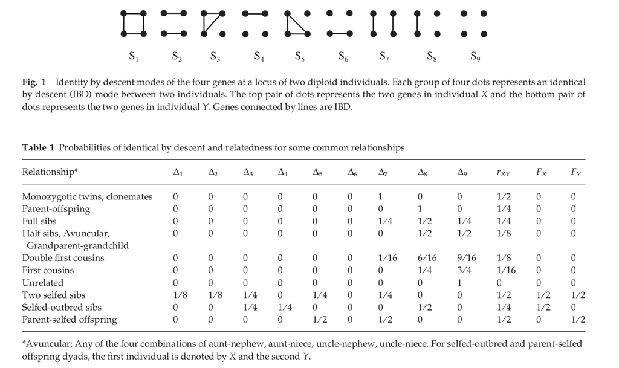

Probabilities of identical by descent and relatedness for some common relationships

### Bonus

**Why the $r_{xy}$ between full sibs is equal to 0.25?**

- Kempthorne pg. 73
- Assuming two individuals (X and Y) and a given locus with four alleles (a,b,c,d) as: X(a,b) and Y (c,d)
- $r_{XY} = \dfrac{1}{4}[P(a=c) + P(a=d) + P(b=c) + P(b=d)]$
- When we cross X and Y, we have the follow configurations for two siblings:

| Share two aleles | Share one allele | Share zero alleles |
| --- | --- | --- |
| ac-ac (1/16) | ac-ad (2/16) | ac-bd (2/16) |
| ad-ad (1/16) | ac-bc (2/16) | ad-bc (2/16) |
| bc-bc (1/16) | ad-bd (2/16) |  |
| bd-bd (1/16) | bc-bc (2/16) |  |
| 4/16 | 8/16 | 4/16 |

S7 = $r = 1/4 [P(a=c) + P(a=d) + P(b=c) + P(b=d)]$  
S7 = $r = 1/4 [1+0+0+1] = \dfrac{1}{2}$

S8 = $r = 1/4 [P(a=c) + P(a=d) + P(b=c) + P(b=d)]$  
S8 = $r = 1/4 [1+0+0+0] = \dfrac{1}{4}$

S9 = $r = 1/4 [P(a=c) + P(a=d) + P(b=c) + P(b=d)]$  
S9 = $r = 1/4 [0+0+0+0] = 0$

On average:

$$r = (1/2 \times 4/16) + (1/4 \times 8/16) + (0 \times 4/16) = 0.25$$

# COANCENTRY software

- [Original paper](https://onlinelibrary.wiley.com/doi/full/10.1111/j.1755-0998.2010.02885.x)
- Estimates of coancetry may be derived in a variety of ways.
- So far, relatedness was presented as expected values given IBD probabilities from a known pedigree
- Marker-based relatedness can be used for unkown pedigree and can also provide more accurate results
- There is not one universal ‘best’ relatedness estimator, and the performance of estimators depends on the characteristics of the data
- [Maximum-likelihood estimators of relatedness](https://www.genetics.org/content/163/3/1153.long) are the most common in the literature
- Common practice: compare the performance of different estimators on a given data set prior to choosing one on which to interpret results
- **Why the COANCENTRY software?**
  - Advantage: There are many different methods for calculating relatedness, COANCESTRY program can estimate relatedness based on seven estimators, making it easy for users to compare the performance of each.
  - Drawback: platform specific, requiring a specific operating system (Windows operating system )
- [related: an R package for analysing pairwise relatedness from codominant molecular markers](https://onlinelibrary.wiley.com/doi/abs/10.1111/1755-0998.12323)
  - The package can estimate pairwise relatedness using the same approaches as available in COANCESTRY.

## Demo

**Information**

- In this practice, do not run the codes at the same time as the instructor
- The main focus, for now, is not to discuss R programming but to focus on the results from the related package.

### Data Set and Objectives

- `GenotypeData` (provided with the package)
- SSR example
- We will use this dataset to, based on the allele frequency of 10 loci, simulate of 100 parent-offspring pairs, 100 full-sib pairs, 100 half-sib pairs, and 100 unrelated pairs
- In a simulated data set, check relatedness and inbreeding values in the simulated data set

### Codes

**Steps**

1. Download the package the original data set: Each row contains data for one individual, as columns represent alleles of SSR markers (represented in the form of molecular size, in base pairs)
2. Simulate a data set of 800 individuals (100 parent-offspring pairs, 100 full-sib pairs, 100 half-sib pairs, and 100 unrelated pairs)
3. `coancestry` calculate relatedness for all pairwise comparisons of the simulated individuals.Using `help(coancestry)` it is possible to observe that the package can compute seven estimators, account for genotyping errors, missing data and inbreeding, and can estimate 95% confidence intervals.
4. `simrel` extract the relatedness values for the specific pairs that we generated of known relatedness.
5. Check relatedness and inbreeding values in the simulated data set

```r
# i) Download
library(related) # after installed the package, require the package
data("GenotypeData") # original data set
dim(GenotypeData) # 10 SSRs vs. 389
head(GenotypeData)

# ii) Simulate a data set
input = readgenotypedata(GenotypeData) # import name and freq of the SSR
input$nalleles #number of alleles per SSR
input$freqs$locus1 # freq of each allele
sim <- familysim (input$freqs, 100) # simulation 100 pairs of parent-offspring, FS,HS and unrelated
dim(sim) # numb indiv: 100 * 4 * 2 pairs = 800
head(sim) # collumns are pairs of SSR

# iii)  Calculate Relatedness using the coancestry
help(coancestry)
    output <- coancestry ( sim , wang =1) # Relatedness using wang method
str(output) #list with relatedness, inbreeding, freq

#  --- Output
head(output$relatedness) # relatedness between all pairs of individuals using wang method
head(output$inbreeding) # inbreeding per individual

# iv) Extract the relatadness result
simrel <- cleanuprvals ( output$relatedness , 100) # internal function
head(simrel) #  relatedness values for the specific pairs that we generated of known relatedness

# v) Plot the relatedness
relvalues <- simrel [ , 6]
hist(relvalues) # all individuals
label1 = rep ( "PO" , 100)
label2 =rep ( "Full" , 100)
label3 = rep ( "Half" , 100)
label4 =rep ( "Unrelated" , 100)
labels <- c ( label1 , label2 , label3 , label4 )
plot ( as.factor ( labels ) , relvalues , ylab = " Relatedness Value " , xlab = " Relatedness " )

hist(output$inbreeding$L3) # Histogram of all inbreeding values
```

### Results

- Results are presented in the original paper

#### Relatedness values

- Simulated data can be analysed to provide information on the degree of resolution that should be expected in real data set
- For example: how well the software should be able to differentiate full- and half-sibs, using molecular data

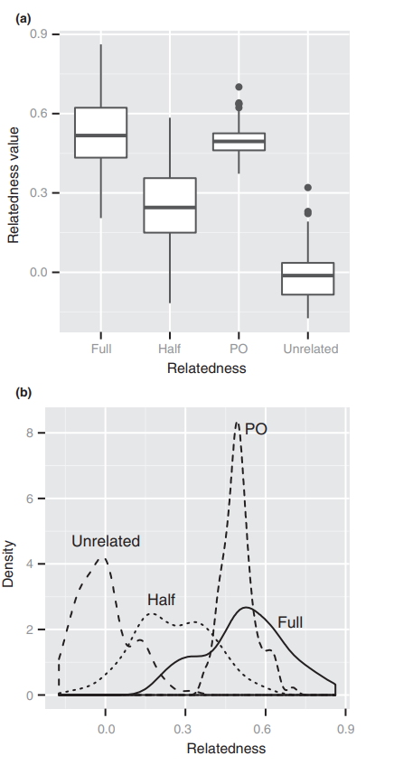

(a) Box plot, and (b) density plot of relatedness values for simulated pairs of individuals of known relatedness

#### Comparing relatedness estimators

- It is well known that there is not one universal ‘best’ relatedness estimator, but rather that the performance of estimators depends on the characteristics of the data

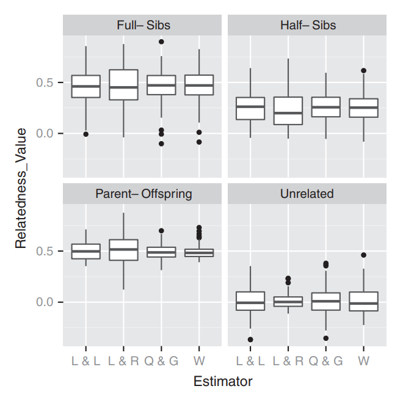

Box plot comparing the relatedness estimates for pairs of simulated individuals of known relatedness using four estimators.

# Conclusion

- In order for the Hardy-Weiberg principle to hold , individuals in a population must mate at random.
- Inbreeding is a form of nonrandom mating based on genetic relationship: it occur when two mating individuals have a common ancestor
- There are different algorithms to compute inbreeding using pedigree records or molecular data
- COANCESTRY is a contemporary software that computes these values easily